# P5-CP1

Estamos analisando dados de encontros romanticos, conhecidos como speed dating que duram aproximadamente 4 minutos, nosso conjunto possui encontros realizados entre 310 pessoas. Nosso dataset eh bem explicativo e possui grande quantidade de variáveis, tais como, raça, campo de estudo, idade das 2 pessoas envolvidas num encontro, genero, cidade que onde os participantes moram, interesses em atividades especificas, classificacoes da propria pessoa e classificacoes para a pessoa com quem se encontrou (quanto achou inteligente, ambicioso, atraente, divertido, etc).

Levantando questionamentos:

1. Para as mulheres, qual a variável (entre atracao e diversao) mais importante para uma nota final, de quanto gostou, do candidato?

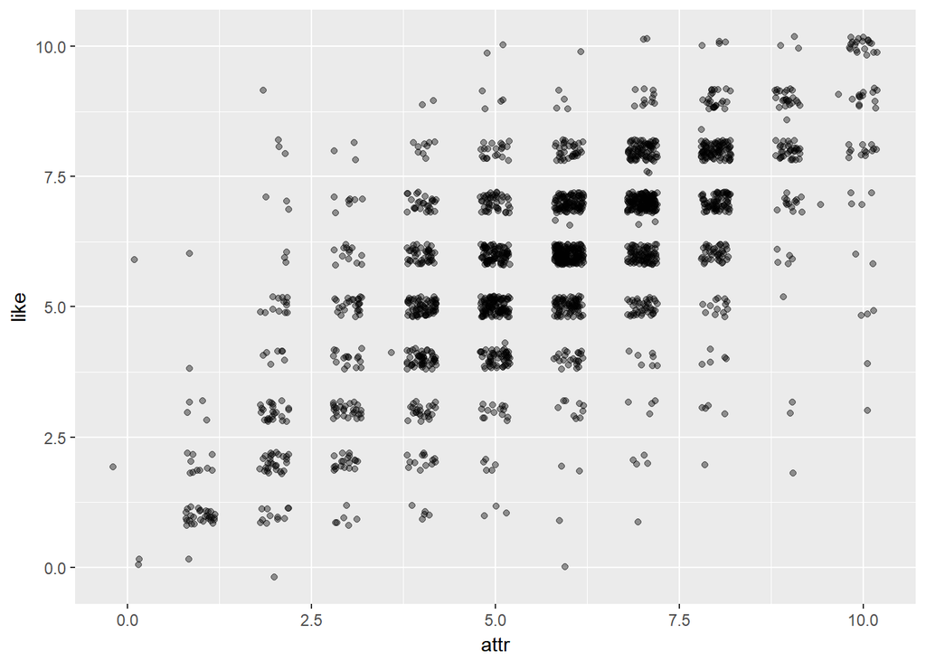

```r
ggplot(dados_mulheres, aes(x = attr, y = like)) +
  geom_jitter(alpha = 0.4)
```

O grafico acima exibe notas dadas aos candidatos dos encontros, no eixo x o quao eh atraente e no eixo y quanto gostou da outra pessoa. Vemos um espalhamento dos dados, com algumas nuvens no meio do grafico, dificultando uma avaliacao do quanto a beleza influencia na nota final recebida pelo candidato.

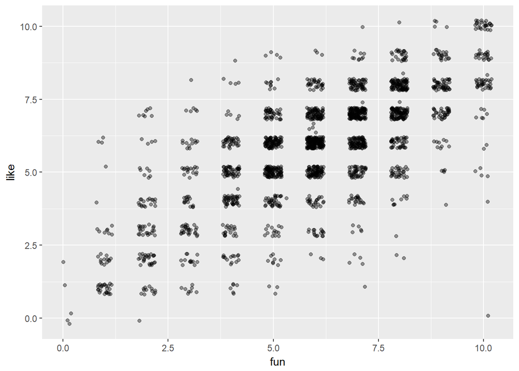

```r
ggplot(dados_mulheres, aes(x = fun, y = like)) +
  geom_jitter(alpha = 0.4)
```

Semelhante ao grafico de beleza, o de diversao, tambem possui grande espalhamento dos dados, e precisamos de um metodo para poder afimar qual das variaveis pesa mais na classificacao final.

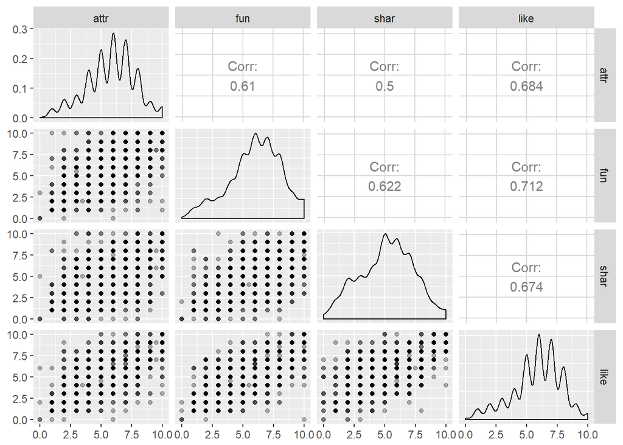

```r
dados_mulheres %>%
  select(attr, fun, shar, like) %>%
  ggpairs(lower = list(continuous = wrap("points", alpha = 0.3)))
```

Acima podemos ver a correlacao entre algumas variaveis, da esquerda para direita (de cima para baixo tambem), atração do candidato, o quão divertido ele eh, o quanto a pessoa acha que compartilha interesses e o quanto ela gostou do candidato. Analisando os numeros podemos notar que a correlacao de atracao/diversao com o quanto a mulher gostou do candidato sao bastante parecidas. vamos tentar analisar de outra forma.

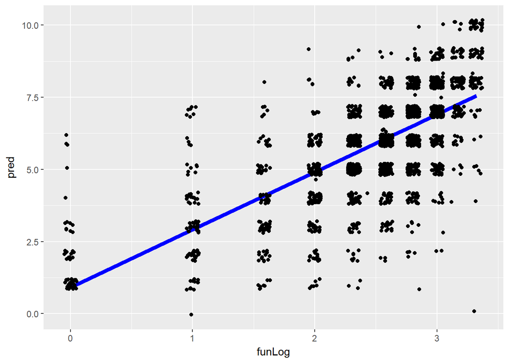

```r
dados_mulheres = dados_mulheres %>%
  filter(fun != 0.0, attr != 0.0) %>%
  mutate(funLog = log2(fun), attrLog = log2(attr))

dados_mulheres.model = lm(like ~ funLog, data = dados_mulheres)

dados_m_augmented = dados_mulheres %>%
  add_predictions(dados_mulheres.model) %>%
  add_residuals(dados_mulheres.model)

# Modelo x dados
dados_m_augmented %>%
  ggplot(aes(x = funLog)) +
  geom_line(aes(y = pred), size = 2, colour = "blue") +
  geom_jitter(aes(y = like))
```

Nesta etapa calculamos os residuos e predicoes, e podemos ver o modelo dos dados juntamente com a predicao. No eixo x temos o logaritmo da variavel ‘diversao’ pois os dados estavam muito espalhados, apesar de continuar, mas ainda seguem um padrão menos disperso, já no eixo y temos a predicao.

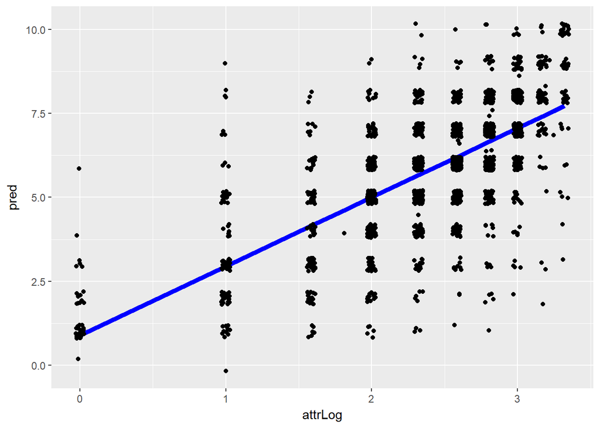

```r
dados_mulheres.modelAttr = lm(like ~ attrLog, data = dados_mulheres)

dados_m_augmented_attr = dados_mulheres %>%
  add_predictions(dados_mulheres.modelAttr) %>%
  add_residuals(dados_mulheres.modelAttr)

# Modelo x dados
dados_m_augmented_attr %>%
  ggplot(aes(x = attrLog)) +
  geom_line(aes(y = pred), size = 2, colour = "blue") +
  geom_jitter(aes(y = like))
```

No grafico acima fizemos o processo semelhante ao do grafico anterior, porem, analisando o logaritmo da variavel ‘atracao’ para a predicao calculada.

```r
tidy(dados_mulheres.model, conf.int = TRUE)
```

```
##          term  estimate  std.error statistic       p.value  conf.low
## 1 (Intercept) 0.9101957 0.11908592  7.643185  3.226439e-14 0.6766543
## 2      funLog 1.9993562 0.04634121 43.144235 2.770312e-290 1.9084757
##   conf.high
## 1  1.143737
## 2  2.090237
```

```r
tidy(dados_mulheres.modelAttr, conf.int = TRUE)
```

```
##          term estimate  std.error statistic       p.value  conf.low
## 1 (Intercept) 0.894000 0.12225885  7.312354  3.739251e-13 0.6542362
## 2     attrLog 2.054868 0.04878905 42.117394 3.533738e-280 1.9591865
##   conf.high
## 1  1.133764
## 2  2.150549
```

Nos dataframes acima podemos ver os intervalos de confianca para o logaritmo da ‘atracao’ e para o logaritmo da variavel ‘diversao’, onde obtivemos intervalos que interceptaram a maior parte dos valores. Para o logaritmo da ‘diversao’ obtivemos o intervalo 1.908~2.09, e para o logaritmo da ‘atracao’ obtivemos o intervalo 1.959~2.15. Intervalos praticamente iguais, podemos afirmar que a diferenca entre eles cruzaria o valor 0, nos levando a afirmar que nao podemos concluir que uma eh mais representativa que outra.

```r
glance(dados_mulheres.model, conf.int = TRUE)
```

```
##   r.squared adj.r.squared    sigma statistic       p.value df    logLik
## 1 0.4746808     0.4744257 1.393139  1861.425 2.770312e-290  2 -3608.526
##        AIC      BIC deviance df.residual
## 1 7223.053 7239.947 3998.123        2060
```

Calculamos o R², que utilizamos para explicar o quanto esse modelo consegue explicar os valores observados. Vemos que o R² teve valor ~0.475, o que nos diz que 47.5% da variavel que nos calculamos como logaritmo da diversao, consegue explicar nossa regressao.

```r
glance(dados_mulheres.modelAttr, conf.int = TRUE)
```

```
##   r.squared adj.r.squared    sigma statistic       p.value df    logLik
## 1 0.4626846     0.4624238 1.408956  1773.875 3.533738e-280  2 -3631.805
##        AIC      BIC deviance df.residual
## 1 7269.611 7286.505 4089.423        2060
```

No caso da variavel logaritmo da atracao, o R² calculado foi ~0.462 valor muito parecido com o da variavel log(diversao), e aqui temos a mesma interpretacao anterior.

2. Quais variaveis (classificacoes para a pessoa com quem se encontrou) explicam melhor a nota atribuida de uma mulher para a pessoa com quem se encontrou?

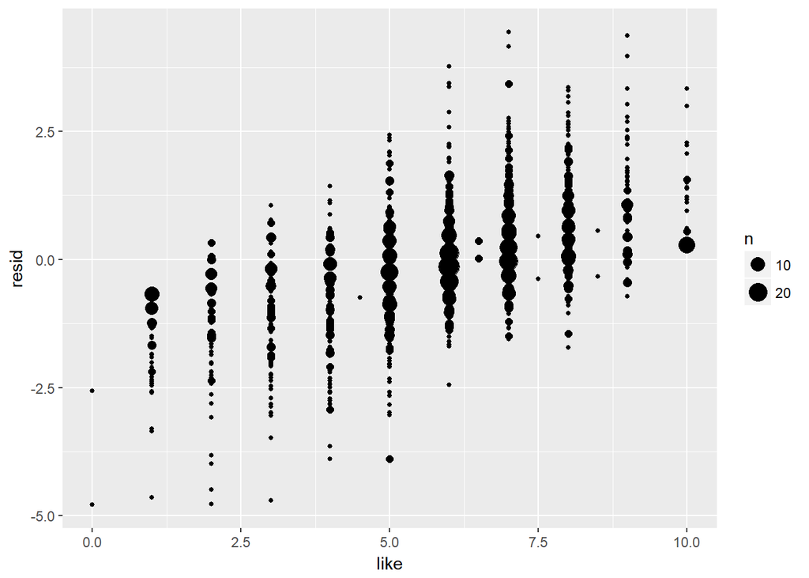

```r
dados_mulheres_multi = lm(like ~ fun + attr + shar, data = subset(dados_mulheres, select = -c(field,from,career)))
adv_augmented = dados_mulheres %>%
  add_predictions(dados_mulheres_multi) %>%
  add_residuals(dados_mulheres_multi)

adv_augmented %>%
  ggplot(aes(x = like)) +
  geom_count(aes(y = resid))
```

```r
glance(dados_mulheres_multi, conf.int = TRUE)
```

```
##   r.squared adj.r.squared    sigma statistic p.value df    logLik      AIC
## 1 0.6596421     0.6591459 1.121919  1329.525       0  4 -3161.064 6332.127
##        BIC deviance df.residual
## 1 6360.285 2590.411        2058
```

```r
tidy(dados_mulheres_multi, conf.int = TRUE)
```

```
##          term  estimate  std.error statistic      p.value  conf.low
## 1 (Intercept) 0.7752770 0.08544890   9.07299 2.632720e-19 0.6077017
## 2         fun 0.2844575 0.01681378  16.91812 3.211789e-60 0.2514837
## 3        attr 0.3343878 0.01605472  20.82801 1.399377e-87 0.3029026
## 4        shar 0.2757695 0.01478461  18.65246 7.274780e-72 0.2467751
##   conf.high
## 1 0.9428523
## 2 0.3174313
## 3 0.3658730
## 4 0.3047638
```

Após alguns ajustes e procurar quais variaveis tinha maior peso na nota final (like), foi possivel concluir que as seguintes 3 variaveis tinham forte impacto na decisao final: atracao, diversao e compartilhar interesses. Como nenhum dos intervalos calculados cruzam o zero, podemos dizer que sao significativas. Ja para o R², tivemos um resultado bem melhor do que com os logaritmos das variaveis calculados na questao anterior, implicando que aproximadamente 65.96% das variaveis que nos calculamos, consegue explicar nossa regressao.